# **Tugas Kuliah MPDW**

Elardian Putera Ramadhan (G1401231042)

2025-09-01

## **Pemanggilan *Packages***

```r
# Memuat pustaka yang diperlukan
library(readxl)
library(ggplot2)
library(dplyr)
library(TTR)
library(forecast)
library(lmtest) #digunakan untuk uji formal pendeteksian autokorelasi
library(orcutt) #untuk membuat model regresi Cochrane-Orcutt
library(HoRM) #untuk membuat model regresi Hildreth-Lu
```

## **Input Data**

Data yang digunakan adalah data IPM Provinsi Banten periode tahun 2010-2024.

```r
# Membaca data dari file Excel
data <- read_excel("C:/Users/Putera Ramadhan/OneDrive/Documents/IPM Terbaru Banten 2010-2024.xlsx")
data
```

```
## # A tibble: 15 × 2
##    Tahun   IPM
##    <dbl> <dbl>
##  1  2010  67.5
##  2  2011  68.2
##  3  2012  68.9
##  4  2013  69.5
##  5  2014  69.9
##  6  2015  70.3
##  7  2016  71.0
##  8  2017  71.4
##  9  2018  72.0
## 10  2019  72.4
## 11  2020  72.4
## 12  2021  72.7
## 13  2022  73.3
## 14  2023  73.9
## 15  2024  74.5
```

```r
# Menampilkan struktur data
str(data)
```

```
## tibble [15 × 2] (S3: tbl_df/tbl/data.frame)
##  $ Tahun: num [1:15] 2010 2011 2012 2013 2014 ...
##  $ IPM  : num [1:15] 67.5 68.2 68.9 69.5 69.9 ...
```

## **Eksplorasi Data**

Sebelum melakukan regresi, akan diperlihatkan *plot time-series* dari IPM Provinsi Banten Periode 2010-2024

```r
# Mengkonversi data menjadi data deret waktu
data_ts <- ts(data$IPM, start = c(2010), frequency = 1)
data_ts
```

```
## Time Series:
## Start = 2010
## End = 2024
## Frequency = 1
##  [1] 67.54 68.22 68.92 69.47 69.89 70.27 70.96 71.42 71.95 72.44 72.45 72.72
## [13] 73.32 73.87 74.48
```

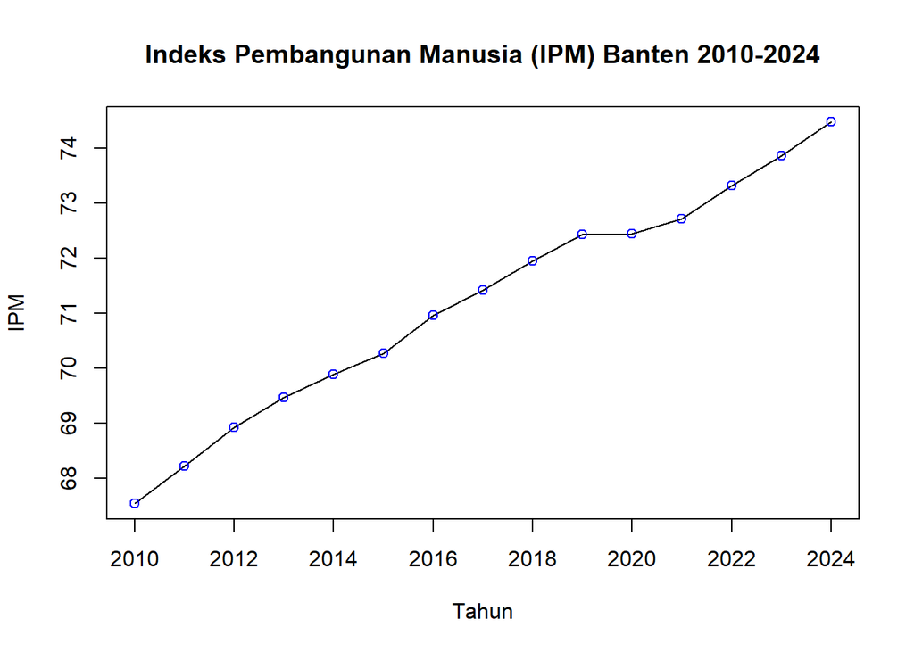

```r
plot(data_ts, main = "Indeks Pembangunan Manusia (IPM) Banten 2010-2024", ylab = "IPM", xlab = "Tahun")
points(data_ts, col = "blue")
```

Berdasarkan plot yang disajikan, terlihat jelas bahwa data IPM Banten memiliki sebuah **tren positif yang kuat**, yang secara langsung mengindikasikan bahwa data ini **tidak stasioner dalam rataan**. Pola pergerakan data yang mulus, di mana nilai pada satu tahun sangat dipengaruhi oleh nilai tahun sebelumnya, merupakan ciri khas dari adanya **autokorelasi positif yang tinggi**. Sementara itu, karena data bersifat tahunan, **tidak ditemukan adanya pola musiman** yang perlu dipertimbangkan dalam analisis lebih lanjut.

Selanjutnya akan dilakukan ramalan dan pemulusan dengan metode DMA dan DES

```r
dt.sma <- SMA(data_ts, n = 3)
dma <- SMA(dt.sma, n = 3)
At <- 2 * dt.sma - dma
Bt <- 2 / (3-1) * (dt.sma - dma)
dt.dma<- At + Bt
dt.ramal<- c(NA, dt.dma)

t = 1:3
f = c()

for (i in t) {
  f[i] = At[length(At)] + Bt[length(Bt)]*(i)
}

dt.gab <- cbind(aktual = c(data_ts,rep(NA,3)),
                pemulusan1 = c(dt.sma,rep(NA,3)),
                pemulusan2 = c(dt.dma, rep(NA,3)),
                At = c(At, rep(NA,3)),
                Bt = c(Bt,rep(NA,3)),
                ramalan = c(dt.ramal, f[-1]))
dt.gab
```

```
##       aktual pemulusan1 pemulusan2       At        Bt  ramalan
##  [1,]  67.54         NA         NA       NA        NA       NA
##  [2,]  68.22         NA         NA       NA        NA       NA
##  [3,]  68.92   68.22667         NA       NA        NA       NA
##  [4,]  69.47   68.87000         NA       NA        NA       NA
##  [5,]  69.89   69.42667   70.59778 70.01222 0.5855556       NA
##  [6,]  70.27   69.87667   70.84778 70.36222 0.4855556 70.59778
##  [7,]  70.96   70.37333   71.33556 70.85444 0.4811111 70.84778
##  [8,]  71.42   70.88333   71.89444 71.38889 0.5055556 71.33556
##  [9,]  71.95   71.44333   72.53000 71.98667 0.5433333 71.89444
## [10,]  72.44   71.93667   72.96778 72.45222 0.5155556 72.53000
## [11,]  72.45   72.28000   73.06667 72.67333 0.3933333 72.96778
## [12,]  72.72   72.53667   73.10778 72.82222 0.2855556 73.06667
## [13,]  73.32   72.83000   73.39222 73.11111 0.2811111 73.10778
## [14,]  73.87   73.30333   74.13000 73.71667 0.4133333 73.39222
## [15,]  74.48   73.89000   74.98778 74.43889 0.5488889 74.13000
## [16,]     NA         NA         NA       NA        NA 74.98778
## [17,]     NA         NA         NA       NA        NA 75.53667
## [18,]     NA         NA         NA       NA        NA 76.08556
```

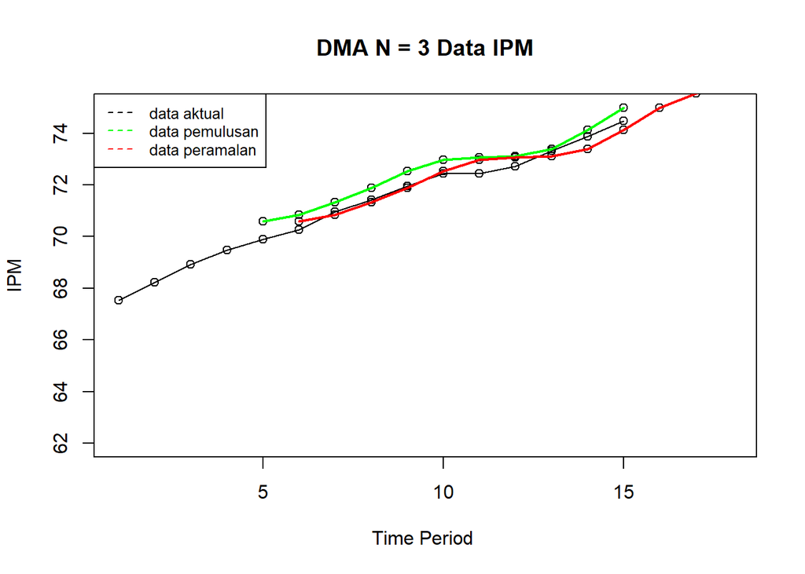

```r
# Plot time series
ts.plot(dt.gab[,1], xlab="Time Period ", ylab="IPM",
        main= "DMA N = 3 Data IPM", ylim=c(62,75))
points(dt.gab[,1])
points(dt.gab[,3])
points(dt.gab[,6])
lines(dt.gab[,3],col="green",lwd=2)
lines(dt.gab[,6],col="red",lwd=2)
legend("topleft",c("data aktual","data pemulusan","data peramalan"),
       lty=8, col=c("black","green","red"), cex=0.8)
```

Selanjutnya akan dilihat keakuratan dari metode DMA

```r
# Menghitung nilai keakuratan
error.dma = data_ts-dt.ramal[1:length(data_ts)]
SSE.dma = sum(error.dma[6:length(data_ts)]^2)
MSE.dma = mean(error.dma[6:length(data_ts)]^2)
MAPE.dma = mean(abs((error.dma[6:length(data_ts)]/data_ts[6:length(data_ts)])*100))

akurasi.dma <- matrix(c(SSE.dma, MSE.dma, MAPE.dma))
row.names(akurasi.dma)<- c("SSE", "MSE", "MAPE")
colnames(akurasi.dma) <- c("Akurasi m = 3")
akurasi.dma
```

```
##      Akurasi m = 3
## SSE     0.92243086
## MSE     0.09224309
## MAPE    0.35418313
```

Selanjutnya akan digunakan metode *Double Exponential Smoothing* dengan cara sebagai berikut.

Pertama akan data akan dibagi menjadi data *training* dan data *testing*.

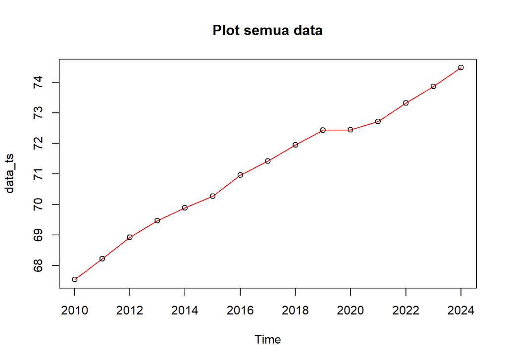

```r
# Membagi training dan testing
training<-data[1:12,2]
testing<-data[13:15,2]

# data time series
training.ts<-ts(training)
testing.ts<-ts(testing, start=13)

# eksplorasi data
plot(data_ts, col="red",main="Plot semua data")
points(data_ts)
```

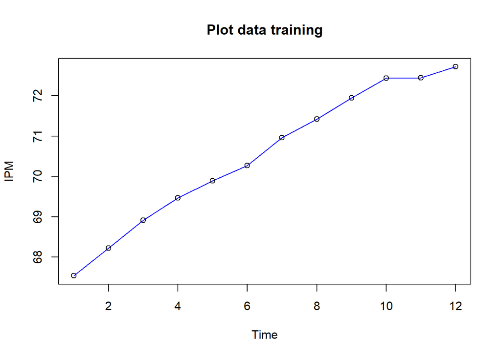

```r
plot(training.ts, col="blue",main="Plot data training")
points(training.ts)
```

Selanjutnya akan dilakukan pemulusan dengan DES, kali ini langsung dicari lambda dan gamma optimum sebagai berikut. Nilai lambda dan gamma optimum dapat dilihat pada smoothing parameters alpha untuk nilai lambda dan beta untuk nilai gamma.

```r
# Lamda dan gamma optimum
des.opt<- HoltWinters(training.ts, gamma = FALSE)
des.opt
```

```
## Holt-Winters exponential smoothing with trend and without seasonal component.
##
## Call:
## HoltWinters(x = training.ts, gamma = FALSE)
##
## Smoothing parameters:
##  alpha: 1
##  beta : 0.4929712
##  gamma: FALSE
##
## Coefficients:
##         [,1]
## a 72.7200000
## b  0.2658199
```

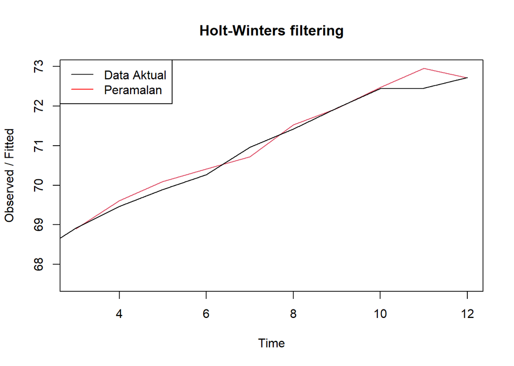

```r
plot(des.opt)
legend("topleft", c("Data Aktual", "Peramalan"), col = c("black", "red"),
       lty = c(1,1))
```

```r
# ramalan
ramalandesopt<- forecast(des.opt, h = 3)
ramalandesopt
```

```
##    Point Forecast    Lo 80    Hi 80    Lo 95    Hi 95
## 13       72.98582 72.74177 73.22987 72.61258 73.35906
## 14       73.25164 72.81311 73.69017 72.58096 73.92232
## 15       73.51746 72.86385 74.17107 72.51785 74.51707
```

1. Model Sangat Cocok dengan Data Historis dan Menangkap Tren Naik  
   Grafik menunjukkan garis Peramalan (merah) yang hampir menempel sempurna pada garis Data Aktual (hitam). Ini berarti model Holt-Winters sangat baik dalam mengikuti pola data historis (good in-sample fit). Pola utama yang ditangkap adalah tren naik (upward trend) yang jelas, tanpa adanya pola musiman.
2. Model Sangat Reaktif Terhadap Perubahan Level Terbaru  
   Parameter alpha: 1 adalah insight paling penting di sini. Nilai alpha 1 berarti model memberikan 100% bobot pada observasi data terbaru untuk menentukan “level” saat ini. Dengan kata lain, model ini mengasumsikan bahwa nilai terakhir adalah representasi terbaik dari kondisi saat ini, mengabaikan level-level sebelumnya. Sementara itu, nilai beta: 0.49 menunjukkan bahwa trennya cukup adaptif, menyeimbangkan antara tren lama dan informasi tren yang baru.
3. Proyeksi Masa Depan Naik Secara Linear, Namun Kepastiannya Menurun  
   Tabel Point Forecast menunjukkan prediksi yang terus meningkat secara konsisten (72.98 -> 73.25 -> 73.51). Kenaikan ini didasarkan pada level akhir (a = 72.72) dan tren akhir (b = 0.26). Namun, yang tak kalah penting, rentang interval kepercayaan (Lo 95 - Hi 95) semakin melebar dari waktu ke waktu. Ini menunjukkan bahwa semakin jauh kita meramal ke masa depan, semakin besar pula ketidakpastiannya.

Selanjutnya akan dicari akurasi dari metode DES.

```r
ssedes.train<-des.opt$SSE
msedes.train<-ssedes.train/length(training.ts)
sisaandes<-ramalandesopt$residuals
head(sisaandes)
```

```
## Time Series:
## Start = 1
## End = 6
## Frequency = 1
##               x
## [1,]         NA
## [2,]         NA
## [3,]  0.0200000
## [4,] -0.1398594
## [5,] -0.2009128
## [6,] -0.1418686
```

```r
mapedes.train <- sum(abs(sisaandes[3:length(training.ts)]/training.ts[3:length(training.ts)])*100)/length(training.ts)

akurasides.opt <- matrix(c(ssedes.train,msedes.train,mapedes.train))
row.names(akurasides.opt)<- c("SSE", "MSE", "MAPE")
colnames(akurasides.opt) <- c("Akurasi lamda dan gamma optimum")
akurasides.opt
```

```
##      Akurasi lamda dan gamma optimum
## SSE                       0.39696206
## MSE                       0.03308017
## MAPE                      0.16418246
```

```r
# Akurasi data testing
selisihdesopt<-ramalandesopt$mean-testing.ts
selisihdesopt
```

```
## Time Series:
## Start = 13
## End = 15
## Frequency = 1
##      testing.ts
## [1,] -0.3341801
## [2,] -0.6183601
## [3,] -0.9625402
```

```r
SSEtestingdesopt<-sum(selisihdesopt^2)
SSEtestingdesopt<-SSEtestingdesopt/length(testing.ts)
MAPEtestingdesopt<-sum(abs(selisihdesopt/testing.ts)*100)/length(testing.ts)

akurasiDesTesting <- matrix(c(SSEtestingdesopt,SSEtestingdesopt,MAPEtestingdesopt))
row.names(akurasiDesTesting)<- c("SSE", "MSE", "MAPE")
colnames(akurasiDesTesting) <- c("Akurasi lamda dan gamma optimum")
akurasiDesTesting
```

```
##      Akurasi lamda dan gamma optimum
## SSE                        0.4735097
## MSE                        0.4735097
## MAPE                       0.8617408
```

Setelah didapatkan nilai akurasi untuk metode DMA dan DES, selanjutnya akan dibandingkan keakuratan antar metode keduanya.

```r
cbind(akurasi.dma, akurasides.opt)
```

```
##      Akurasi m = 3 Akurasi lamda dan gamma optimum
## SSE     0.92243086                      0.39696206
## MSE     0.09224309                      0.03308017
## MAPE    0.35418313                      0.16418246
```

Berdasarkan perbandingan akurasi tersebut, terlihat nilai SSE, MSE, dan MAPE metode DES lebih kecil dibandingkan dengan metode DMA. Oleh karena itu, metode peramalan dan pemulusan yang terbaik antara keduanya adalah dengan metode DES.

Setelah melakukan peramalan, data yang telah dimasukkan kemudian dieksplorasi. Eksplorasi pertama yang dilakukan adalah dengan menggunakan *scatter plot*.

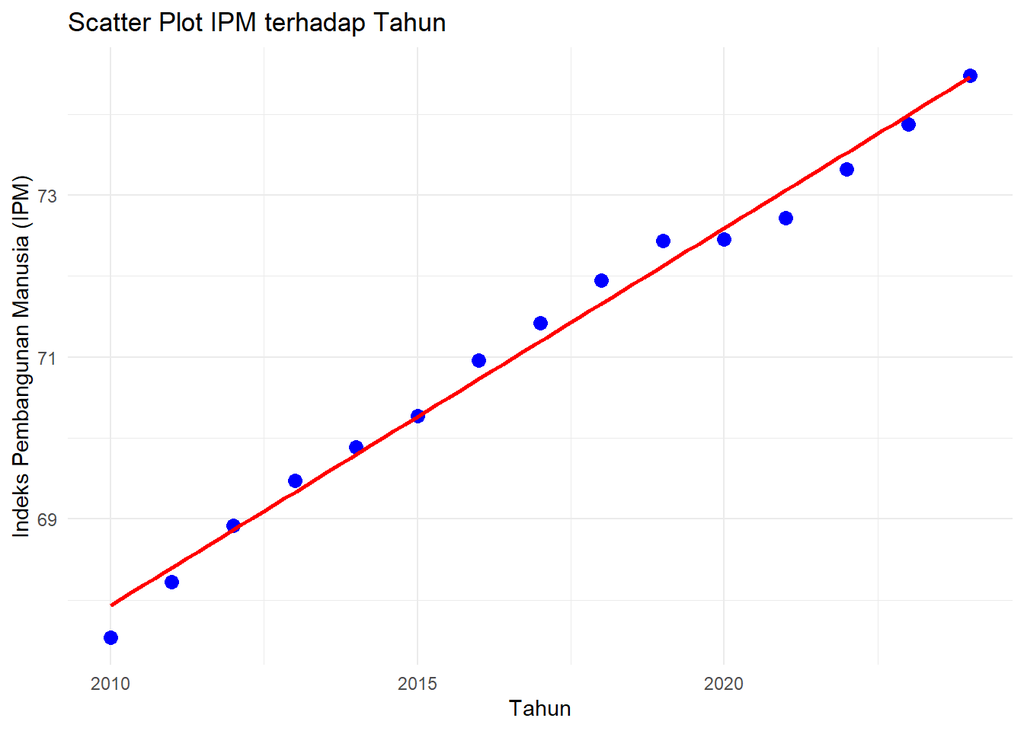

```r
# Scatter plot IPM terhadap Tahun
ggplot(data, aes(x = Tahun, y = IPM)) +
  geom_point(color = "blue", size = 3) +
  geom_smooth(method = "lm", se = FALSE, color = "red") +
  labs(title = "Scatter Plot IPM terhadap Tahun",
       x = "Tahun",
       y = "Indeks Pembangunan Manusia (IPM)") +
  theme_minimal()
```

```r
# Menampilkan nilai korelasi
correlation <- cor(data$Tahun, data$IPM)
print(paste("Korelasi antara Tahun dan IPM:", round(correlation, 4)))
```

```
## [1] "Korelasi antara Tahun dan IPM: 0.9943"
```

Berdasarkan scatter plot di atas, terlihat adanya hubungan / korelasi positif antara peubah tahun dengan nilai IPM, terlihat titik-titik pada plot yang naik ke arah kanan atas. Hal tersebut juga diperkuat dengan hasil perhitungan aplikasi `R` di mana didapatkan nilai korelasi sebesar $0.9943$.

Setalah mengetahui adanya hubungan antar dua peubah, maka model regresi dapat ditentukan.

## **Model Regresi Linier Sederhana dan Uji Autokorelasi**

```r
# Membuat model regresi linier
model <- lm(IPM ~ Tahun, data = data)
summary(model)
```

```
##
## Call:
## lm(formula = IPM ~ Tahun, data = data)
##
## Residuals:
##      Min       1Q   Median       3Q      Max
## -0.39242 -0.16061  0.02308  0.18240  0.31326
##
## Coefficients:
##               Estimate Std. Error t value Pr(>|t|)
## (Intercept) -868.79937   27.88223  -31.16 1.34e-13 ***
## Tahun          0.46604    0.01382   33.71 4.85e-14 ***
## ---
## Signif. codes:  0 '***' 0.001 '**' 0.01 '*' 0.05 '.' 0.1 ' ' 1
##
## Residual standard error: 0.2313 on 13 degrees of freedom
## Multiple R-squared:  0.9887, Adjusted R-squared:  0.9878
## F-statistic:  1137 on 1 and 13 DF,  p-value: 4.852e-14
```

Model yang dihasilkan adalah
$$y_i=-868.79937+0.46604x_t$$
Berdasarkan ringkasan model dapat diketahui bahwa hasil uji F memiliki *p-value* < $\alpha$ (5%). Artinya, minimal terdapat satu variabel yang berpengaruh nyata terhadap model. Hasil uji-t parsial kedua parameter regresi, yaitu intersep dan koefisien regresi juga menunjukkan hal yang sama, yaitu memiliki *p-value* < $\alpha$ (5%) sehingga nyata dalam taraf 5%. Selanjutnya dapat dilihat juga nilai $R^2=0.9878$. Artinya, sebesar 98.78% keragaman nilai IPM dapat dijelaskan oleh peubah tahun. Hasil ini menunjukkan hasil yang bagus, seolah mendapatkan hasil terbaik. Namun, kita perlu melakukan uji terhadap sisaannya seperti berikut ini.

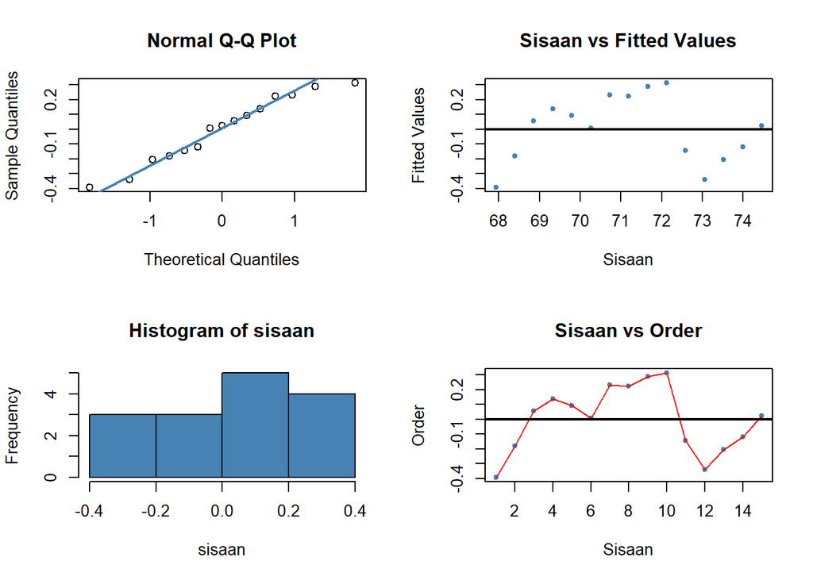

```r
# Sisaan dan fitted value
sisaan <- residuals(model)
fitValue <- predict(model)

# Diagnostik dengan eksploratif
par(mfrow = c(2,2))
qqnorm(sisaan)
qqline(sisaan, col = "steelblue", lwd = 2)
plot(fitValue, sisaan, col = "steelblue", pch = 20, xlab = "Sisaan", ylab = "Fitted Values", main = "Sisaan vs Fitted Values")
abline(a = 0, b = 0, lwd = 2)
hist(sisaan, col = "steelblue")
plot(seq(1,15,1), sisaan, col = "steelblue", pch = 20, xlab = "Sisaan", ylab = "Order", main = "Sisaan vs Order")
lines(seq(1,15,1), sisaan, col = "red")
abline(a = 0, b = 0, lwd = 2)
```

Dua plot di samping kiri digunakan untuk melihat apakah sisaan menyebar normal. **Normal Q-Q Plot** di atas menunjukkan bahwa titik-titik tidak sepenuhnya mengikuti garis lurus, meskipun sebagian besar masih cukup dekat, sehingga sisaan hanya mendekati normal. Sementara itu, **Histogram of sisaan** di bawah terlihat kurang simetris dan agak menyebar tidak merata, sehingga distribusi sisaan tidak sepenuhnya normal.

Selanjutnya, dua plot di samping kanan digunakan untuk melihat autokorelasi. **Plot Sisaan vs Fitted Values** menunjukkan adanya sebaran yang tidak acak karena masih terlihat beberapa pola titik di atas dan di bawah garis nol. Sedangkan **Plot Sisaan vs Order** juga menunjukkan adanya fluktuasi pola yang cenderung berulang, sehingga mengindikasikan adanya autokorelasi. Untuk lebih lanjut akan digunakan uji formal melihat normalitas sisaan dan plot ACF dan PACF untuk melihat apakah ada autokorelasi atau tidak.

```r
# Uji normalitas sisaan dengan Shapiro-Wilk dan Kormogorov-Smirnov
# H0: sisaan mengikuti sebaran normal
# H1: sisaan tidak mengikuti sebaran normal
shapiro_test <- shapiro.test(sisaan)
ks_test <- ks.test(sisaan, "pnorm", mean = mean(sisaan), sd = sd(sisaan))
print(shapiro_test)
```

```
##
##  Shapiro-Wilk normality test
##
## data:  sisaan
## W = 0.95481, p-value = 0.6031
```

```r
print(ks_test)
```

```
##
##  Exact one-sample Kolmogorov-Smirnov test
##
## data:  sisaan
## D = 0.11325, p-value = 0.9787
## alternative hypothesis: two-sided
```

Berdasarkan uji formal Saphiro-Wilk dan Kolmogorov-Smirnov didapatkan nilai *p-value* > $\alpha$ (5%). Artinya, cukup bukti untuk menyatakan sisaan berdistribusi normal.

Selanjutnya akan dilakukan uji autokorelasi dengan uji Durbin-Watson dan plot ACF dan PACF.

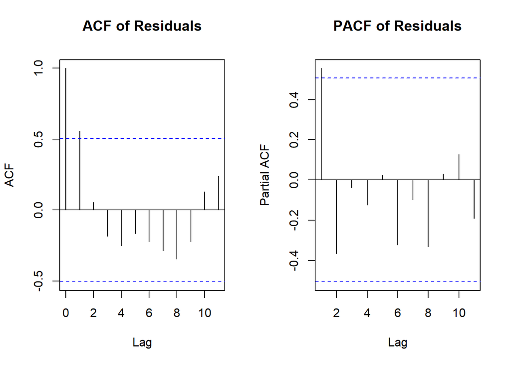

```r
# Plot ACF dan PACF sisaan
par(mfrow = c(1,2))
acf(sisaan, main = "ACF of Residuals")
pacf(sisaan, main = "PACF of Residuals")
```

Plot **ACF of Residuals** menunjukkan bahwa pada lag 1 terdapat nilai autokorelasi yang melewati batas signifikansi, sehingga mengindikasikan adanya autokorelasi pada sisaan. Sementara itu, plot **PACF of Residuals** memperlihatkan bahwa sebagian besar lag berada dalam batas signifikansi, meskipun pada lag awal terdapat sedikit indikasi pengaruh. Secara keseluruhan, kedua plot ini mengonfirmasi bahwa sisaan belum sepenuhnya bebas dari autokorelasi.

Namun, untuk memastikan adanya autokorelasi, akan dilakukan uji formal Durbin-Watson sebagai berikut.

```r
# Melakukan uji Durbin-Watson untuk autokorelasi
# H0: tidak ada autokorelasi
# H1: ada autokorelasi
dw_test <- dwtest(model)
print(dw_test)
```

```
##
##  Durbin-Watson test
##
## data:  model
## DW = 0.66718, p-value = 0.0002458
## alternative hypothesis: true autocorrelation is greater than 0
```

Berdasarkan hasil DW Test, didapatkan nilai $DW = 0.66718$ dan *p-value* = $0.0002458$. Berdasarkan tabel Durbin-Watson, nilai DW ini berada di daerah yang menunjukkan adanya **autokorelasi positif** (nilai $DW < DL$). Kesimpulan ini diperkuat oleh nilai *p-value* yang jauh lebih kecil dari 0.05, sehingga dapat disimpulkan untuk menolak H0 dan terdapat cukup bukti statistik untuk menyatakan adanya autokorelasi. Oleh karena itu, diperlukan penanganan autokorelasi. Penanganan yang akan digunakan menggunakan dua metode, yaitu Cochrane-Orcutt dan Hildreth-Lu.

## **Penanganan Autokorelasi**

### **Metode Cochrane-Orcutt**

Penanganan metode Cochrane-Orcutt dapat dilakukan dengan bantuan packages Orcutt pada aplikasi `R` maupun secara manual. Berikut ini ditampilkan cara menggunakan bantuan `library` *packages* `Orcutt`.

```r
# Menggunakan metode Cochrane-Orcutt
model_cochrane <- cochrane.orcutt(model)
model_cochrane
```

```
## Cochrane-orcutt estimation for first order autocorrelation
##
## Call:
## lm(formula = IPM ~ Tahun, data = data)
##
##  number of interaction: 14
##  rho 0.553602
##
## Durbin-Watson statistic
## (original):    0.66718 , p-value: 2.458e-04
## (transformed): 1.49571 , p-value: 9.107e-02
##
##  coefficients:
## (Intercept)       Tahun
## -812.135765    0.437999
```

Hasil keluaran model setelah dilakukan penanganan adalah sebagai berikut.
$$IPM_t=-812.135765+0.437999 \cdot
Tahun_t$$
Hasil juga menunjukkan bahwa nilai DW dan p-value meningkat menjadi $1.49571$ dan $0.09107$. Nilai DW sekarang berada pada daerah yang tidak terdeteksi adanya autokorelasi. Hal tersebut juga didukung dengan nilai *p-value* > 0.05, artinya **tidak cukup bukti** untuk menyatakan bahwa sisaan (residual) memiliki autokorelasi pada taraf nyata 5%. Untuk nilai $ρ ̂$ optimum yang digunakan dalam transformasi model adalah $0.553602$. Nilai tersebut didapatkan dari prosedur iteratif Cochrane-Orcutt sebanyak 14 kali.

```r
# Rho optimum
rho <- model_cochrane$rho
rho
```

```
## [1] 0.5536016
```

Selanjutnya akan dilakukan transformasi secara manual dengan syntax berikut ini.

```r
# Transformasi manual dengan metode Cochrane-Orcutt
data$IPM
```

```
##  [1] 67.54 68.22 68.92 69.47 69.89 70.27 70.96 71.42 71.95 72.44 72.45 72.72
## [13] 73.32 73.87 74.48
```

```r
data$IPM[-1]
```

```
##  [1] 68.22 68.92 69.47 69.89 70.27 70.96 71.42 71.95 72.44 72.45 72.72 73.32
## [13] 73.87 74.48
```

```r
ipm.trans <- data$IPM[-1] - data$IPM[-15] * rho
tahun.trans <- data$Tahun[-1] - data$Tahun[-15] * rho
modelCOmanual <- lm(ipm.trans ~ tahun.trans)
summary(modelCOmanual)
```

```
##
## Call:
## lm(formula = ipm.trans ~ tahun.trans)
##
## Residuals:
##      Min       1Q   Median       3Q      Max
## -0.31385 -0.06776  0.02795  0.12191  0.17955
##
## Coefficients:
##               Estimate Std. Error t value Pr(>|t|)
## (Intercept) -362.53611   20.42811  -17.75 5.60e-10 ***
## tahun.trans    0.43800    0.02267   19.32 2.09e-10 ***
## ---
## Signif. codes:  0 '***' 0.001 '**' 0.01 '*' 0.05 '.' 0.1 ' ' 1
##
## Residual standard error: 0.1526 on 12 degrees of freedom
## Multiple R-squared:  0.9689, Adjusted R-squared:  0.9663
## F-statistic: 373.3 on 1 and 12 DF,  p-value: 2.086e-10
```

```r
# Mencari Penduga Koefisien Regresi setelah Transformasi ke Persamaan Awal
b0bintang <- modelCOmanual$coefficients[-2]
b0 <- b0bintang/(1 - rho)
b1 <- modelCOmanual$coefficients[-1]
b0
```

```
## (Intercept)
##   -812.1358
```

```r
b1
```

```
## tahun.trans
##    0.437999
```

Hasil perhitungan koefisien regresi tersebut akan menghasilkan hasil yang sama dengan model yang dihasilkan menggunakan *packages*.

### **Metode Hildreth-Lu**

Penanganan kedua adalah menggunakan metode Hildreth-Lu. Metode ini akan mencari nilai SSE terkecil dan dapat dicari secara manual maupun menggunakan packages. Jika menggunakan packages, gunakan `library` *packages* `HORM`.

```r
# Menggunakan metode Hildreth-Lu
# Ambil y dan x (satu prediktor saja)
y <- data$IPM
x <- data$Tahun

# grid search rho 0–0.9
r <- seq(0, 0.9, by = 0.1)
tab <- data.frame(
  rho = r,
  SSE = sapply(r, function(rr) deviance(hildreth.lu(y, x, rr)))
)

tab            # tabel rho vs SSE
```

```
##    rho       SSE
## 1  0.0 0.4925081
## 2  0.1 0.4225206
## 3  0.2 0.3664304
## 4  0.3 0.3242377
## 5  0.4 0.2959423
## 6  0.5 0.2815444
## 7  0.6 0.2810439
## 8  0.7 0.2944407
## 9  0.8 0.3217350
## 10 0.9 0.3629267
```

```r
rho_hat <- tab$rho[which.min(tab$SSE)]   # rho terbaik
fit_hl  <- hildreth.lu(y, x, rho_hat)    # model final
summary(fit_hl)
```

```
##
## Call:
## lm(formula = y ~ x)
##
## Residuals:
##      Min       1Q   Median       3Q      Max
## -0.32855 -0.06049  0.03362  0.11327  0.17919
##
## Coefficients:
##               Estimate Std. Error t value Pr(>|t|)
## (Intercept) -322.29316   20.48533  -15.73 2.25e-09 ***
## x              0.43484    0.02537   17.14 8.37e-10 ***
## ---
## Signif. codes:  0 '***' 0.001 '**' 0.01 '*' 0.05 '.' 0.1 ' ' 1
##
## Residual standard error: 0.153 on 12 degrees of freedom
## Multiple R-squared:  0.9608, Adjusted R-squared:  0.9575
## F-statistic: 293.9 on 1 and 12 DF,  p-value: 8.367e-10
```

```r
# Penanganan Autokorelasi Hildreth lu
# Hildreth-Lu
hildreth.lu.func<- function(r, model){
  x <- model.matrix(model)[,-1]
  y <- model.response(model.frame(model))
  n <- length(y)
  t <- 2:n
  y <- y[t]-r*y[t-1]
  x <- x[t]-r*x[t-1]

  return(lm(y~x))
}

#Pencariab rho yang meminimumkan SSE
r <- c(seq(0.1,0.9, by= 0.1))
tab <- data.frame("rho" = r, "SSE" = sapply(r, function(i){deviance(hildreth.lu.func(i, model))}))
round(tab, 4)
```

```
##   rho    SSE
## 1 0.1 0.4225
## 2 0.2 0.3664
## 3 0.3 0.3242
## 4 0.4 0.2959
## 5 0.5 0.2815
## 6 0.6 0.2810
## 7 0.7 0.2944
## 8 0.8 0.3217
## 9 0.9 0.3629
```

Pertama-tama akan dicari di mana kira-kira $ρ$ yang menghasilkan SSE minimum. Pada hasil di atas terlihat SSE mencapai nilai minimumnya, yaitu **0.2810**, ketika $ρ$ bernilai **0.6**. Namun, hasil tersebut masih kurang teliti sehingga akan dicari kembali $ρ$ yang lebih optimum dengan ketelitian yang lebih. Jika sebelumnya jarak antar $ρ$ yang dicari adalah 0.1, kali ini jarak antar $ρ$ dapat diperkecil menjadi 0.001 dan dilakukan pada selang **0.5 sampai dengan 0.7** untuk menemukan nilai yang paling optimal.

```r
# Pencarian rho yang lebih teliti
rOpt <- seq(0.5, 0.7, by = 0.001)
tabOpt <- data.frame("rho" = rOpt, "SSE" = sapply(rOpt, function(i){deviance(hildreth.lu.func(i, model))}))
round(tabOpt, 4)
```

```
##       rho    SSE
## 1   0.500 0.2815
## 2   0.501 0.2815
## 3   0.502 0.2814
## 4   0.503 0.2813
## 5   0.504 0.2813
## 6   0.505 0.2812
## 7   0.506 0.2811
## 8   0.507 0.2811
## 9   0.508 0.2810
## 10  0.509 0.2809
## 11  0.510 0.2809
## 12  0.511 0.2808
## 13  0.512 0.2808
## 14  0.513 0.2807
```

[output cut: 187 more lines]

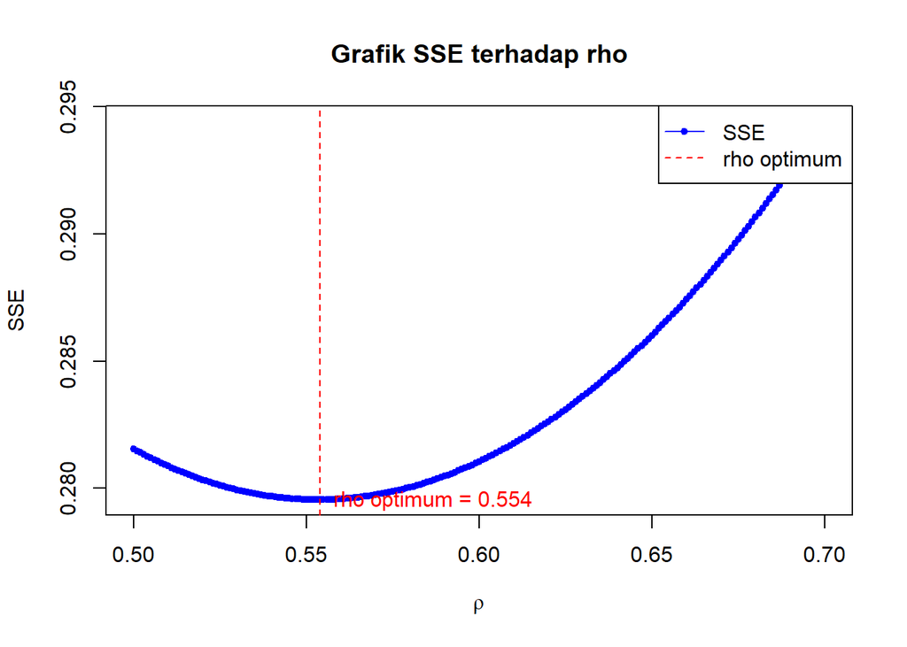

```r
# Grafik SSE Optimum
plot(tabOpt$rho, tabOpt$SSE, type = "b", col = "blue", pch = 20,
     xlab = expression(rho), ylab = "SSE",
     main = "Grafik SSE terhadap rho")
abline(v = tabOpt$rho[which.min(tabOpt$SSE)], col = "red", lty = 2)
legend("topright", legend = c("SSE", "rho optimum"), col = c("blue", "red"), pch = c(20, NA), lty = c(1, 2))
text(tabOpt$rho[which.min(tabOpt$SSE)], min(tabOpt$SSE),
     labels = paste("rho optimum =", round(tabOpt$rho[which.min(tabOpt$SSE)], 3)),
     pos = 4, col = "red")
```

Perhitungan yang dilakukan aplikasi `R` menunjukkan bahwa nilai $ρ$ optimum, yaitu saat SSE terkecil terdapat pada nilai $ρ = 0.554$. Hal tersebut juga ditunjukkan pada plot. Selanjutnya, model dapat didapatkan dengan mengevaluasi nilai $ρ$ ke dalam fungsi `hildreth.lu.func`, serta dilanjutkan dengan pengujian autokorelasi dengan uji Durbin-Watson. Namun, setelah pengecekan tersebut tidak lupa koefisien regresi tersebut digunakan untuk transformasi balik. Persamaan hasil transformasi itulah yang menjadi persamaan sesungguhnya.

```r
# Model Hildreth-Lu dengan rho optimum
model_hl <- hildreth.lu.func(0.554, model)
summary(model_hl)
```

```
##
## Call:
## lm(formula = y ~ x)
##
## Residuals:
##      Min       1Q   Median       3Q      Max
## -0.31398 -0.06765  0.02798  0.12182  0.17955
##
## Coefficients:
##               Estimate Std. Error t value Pr(>|t|)
## (Intercept) -362.19056   20.42813  -17.73 5.67e-10 ***
## x              0.43797    0.02269   19.30 2.11e-10 ***
## ---
## Signif. codes:  0 '***' 0.001 '**' 0.01 '*' 0.05 '.' 0.1 ' ' 1
##
## Residual standard error: 0.1526 on 12 degrees of freedom
## Multiple R-squared:  0.9688, Adjusted R-squared:  0.9662
## F-statistic: 372.6 on 1 and 12 DF,  p-value: 2.109e-10
```

```r
# Transformasi balik
cat("Persamaan regresi Hildreth-Lu: \n")
```

```
## Persamaan regresi Hildreth-Lu:
```

```r
b0_hl <- model_hl$coefficients[1] / (1 - 0.554)
b1_hl <- model_hl$coefficients[2]
cat("IPM_t =", round(b0_hl, 6), "+", round(b1_hl, 6), "* Tahun_t\n")
```

```
## IPM_t = -812.0865 + 0.437975 * Tahun_t
```

```r
# Uji Durbin-Watson pada model Hildreth-Lu
dw_test_hl <- dwtest(model_hl)
print(dw_test_hl)
```

```
##
##  Durbin-Watson test
##
## data:  model_hl
## DW = 1.496, p-value = 0.09119
## alternative hypothesis: true autocorrelation is greater than 0
```

Hasil uji Durbin-Watson juga menunjukkan bawah nilai DW sebesar $1.496$ berada pada selang daerah tidak ada autokorelasi, yaitu pada rentang DU < DW < 4-DU. Hal tersebut juga didukung oleh *p-value* sebesar $0.09119$, di mana *p-value* > $\alpha$=5%. Artinya tak tolak $H_0$ atau belum cukup bukti menyatakan bahwa ada autokorelasi dalam data nilai IPM dengan metode Hildreth-Lu pada taraf nyata 5%.

Terakhir, akan dibandingkan nilai SSE dari ketiga metode (metode awal, metode Cochrane-Orcutt, dan Hildreth-Lu).

```r
# Perbandingan nilai SSE dari ketiga metode
sse_original <- sum(residuals(model)^2)
sse_cochrane <- sum(residuals(model_cochrane)^2)
sse_hildreth <- sum(residuals(model_hl)^2)
sse_comparison <- data.frame(
  Method = c("Original", "Cochrane-Orcutt", "Hildreth-Lu"),
  SSE = c(sse_original, sse_cochrane, sse_hildreth)
)
sse_comparison
```

```
##            Method       SSE
## 1        Original 0.6955730
## 2 Cochrane-Orcutt 1.1093238
## 3     Hildreth-Lu 0.2795481
```

Berdasarkan perbandingan nilai **Sum of Squared Errors (SSE)**, yang mengukur total kesalahan kuadrat dari sebuah model, dapat disimpulkan bahwa metode **Hildreth-Lu** merupakan yang **terbaik** karena memiliki **nilai SSE terendah (0.2795481)**, yang menandakan tingkat kesalahan prediksi paling kecil dan model yang paling akurat. Sebaliknya, model **Original** memiliki kesalahan sebesar 0.6955730, sementara metode **Cochrane-Orcutt** justru menghasilkan model yang **lebih buruk** dengan **SSE tertinggi (1.1093238)**, menunjukkan bahwa penerapannya dalam kasus ini tidak efektif dan bahkan menurunkan akurasi model.

## **Kesimpulan**

Berdasarkan analisis yang telah dilakukan, dapat disimpulkan beberapa hal sebagai berikut:  
1. Data IPM Provinsi Banten periode 2010-2024 menunjukkan tren positif yang kuat, mengindikasikan peningkatan IPM dari tahun ke tahun tanpa adanya pola musiman.  
2. Metode peramalan dan pemulusan yang paling akurat untuk data ini adalah **Double Exponential Smoothing (DES)**, yang menunjukkan nilai SSE, MSE, dan MAPE terendah dibandingkan dengan metode DMA.  
3. Model regresi linier sederhana yang dibangun menunjukkan hubungan positif yang signifikan antara tahun dan IPM, dengan nilai $R^2$ sebesar 98.78%, namun model awal menunjukkan adanya autokorelasi pada sisaan.  
4. Penanganan autokorelasi menggunakan metode **Hildreth-Lu** terbukti paling efektif, menghasilkan model dengan nilai SSE terendah (0.2795481) dibandingkan dengan metode Cochrane-Orcutt dan model awal.  
5. Secara keseluruhan, analisis ini menegaskan pentingnya pemilihan metode yang tepat dalam peramalan dan penanganan autokorelasi untuk mendapatkan model yang akurat dan dapat diandalkan dalam konteks pembangunan manusia di Provinsi Banten.